# Final Project

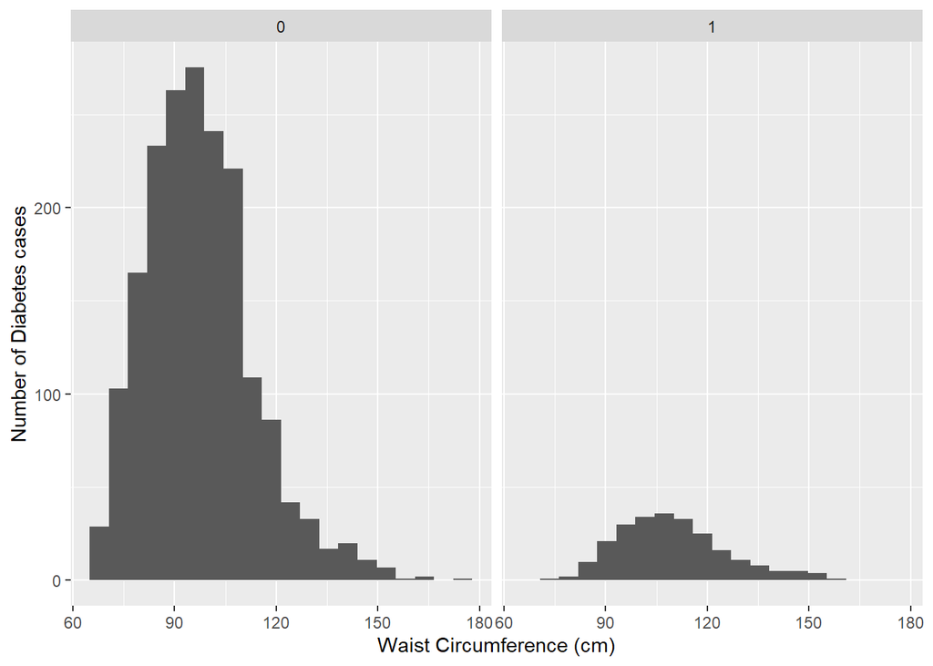

```r
# The mean Direct HDL-Cholesterol is slightly different among people with diabetes and those without diabetes. People without diabetes has a slightly higher mean Direct HDL-Cholesterol than those with diabetes.


BMXWAISTplot <- final_df %>%
  ggplot(aes(x = BMXWAIST)) +
  geom_histogram(bins = 20) +
  labs(x= "Waist Circumference (cm)", y="Number of Diabetes cases")+
  facet_wrap(~ DIQ010)
BMXWAISTplot
```

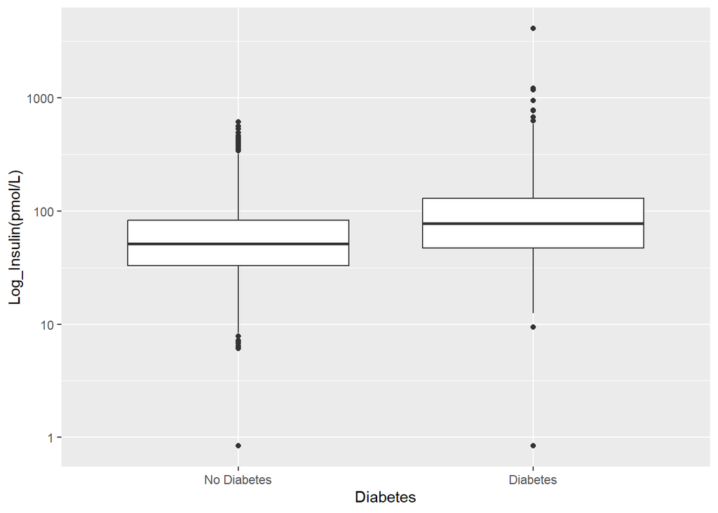

```r
# The distribution of mean waist circumference is different among people with diabetes and those without diabetes. There is a higher mean waist circumference among people with diabetes.

LBDINSIplot<- ggplot(final_df, aes(x = factor(DIQ010), y = LBDINSI)) + geom_boxplot()+scale_y_log10()+labs(x="Diabetes", y= "Log_Insulin(pmol/L)") + scale_x_discrete(labels = c("0"="No Diabetes", "1"="Diabetes"))
LBDINSIplot
```

```r
# In this graph, we can see that the median insulin level is higher in the diabetes participants compared to that of non-diabetes participants.
```

3. Machine Learning  
   3.1 Associations among variables

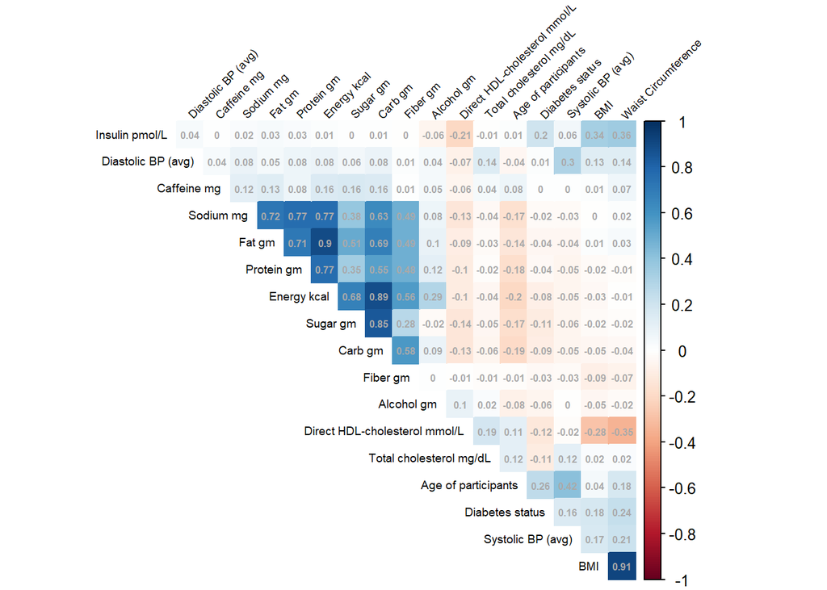

```r
## heatmap
# Convert factors to numeric
numeric_df <- final_df %>%
  mutate(RIAGENDR = as.numeric(as.character(RIAGENDR)),
         DMDEDUC = as.numeric(as.character(DMDEDUC)))
# Ensure no constant columns
numeric_df <- numeric_df %>%
  select_if(~var(.) != 0)

# Compute correlation matrix
correlation_matrix <- cor(numeric_df, use = "pairwise.complete.obs")

# rename variables for readability
actual_names <- c(
  DIQ010 = "Diabetes status",
  RIAGENDR = "Gender of participants",
  RIDAGEYR = "Age of participants",
  DMDEDUC = "Highest grade or level of school",
  BPXDI = "Diastolic BP (avg)",
  BPXSY = "Systolic BP (avg)",
  BMXBMI = "BMI",
  BMXWAIST = "Waist Circumference",
  DR1TKCAL = "Energy kcal",
  DR1TPROT = "Protein gm",
  DR1TTFAT = "Fat gm",
  DR1TCARB = "Carb gm",
  DR1TFIBE = "Fiber gm",
  DR1TSUGR = "Sugar gm",
  DR1TSODI = "Sodium mg",
  DR1TALCO = "Alcohol gm",
  DR1TCAFF = "Caffeine mg",
  LBXTC = "Total cholesterol mg/dL",
  LBDHDDSI = "Direct HDL-cholesterol mmol/L",
  LBDINSI = "Insulin pmol/L"
)


# Ensure  'actual_names' correspond to 'correlation_matrix'
colnames(correlation_matrix) <- actual_names[colnames(correlation_matrix)]
rownames(correlation_matrix) <- actual_names[rownames(correlation_matrix)]

# heatmap with adjusted label and number sizes
corrplot(correlation_matrix, method = "color", order = "AOE", addCoef.col = "dark grey",
         tl.col = "black", tl.srt = 45, tl.cex = 0.6, number.cex = 0.5, # Adjust these values as needed
         type = "upper", diag = FALSE)
```

3.2 Model Building

```r
set.seed(123)
# split training and testing sets
index <- createDataPartition(final_df$DIQ010, p = 0.7, list = TRUE)
train_set <- final_df[index[[1]], ]
test_set <- final_df[-index[[1]], ]
```

3.2.1 Logistic regression

```r
## 1.logistic regression
logit_model <- glm(DIQ010 ~ ., data = train_set, family = "binomial")

# Predict
logit_predictions_prob <- predict(logit_model, newdata = test_set, type = "response")
logit_predictions_label <- ifelse(logit_predictions_prob > 0.5, 1, 0)

# diagnostics
logit_conf_matrix <- table(test_set$DIQ010, logit_predictions_label)
logit_accuracy <- mean(logit_predictions_label == test_set$DIQ010)
logit_sensitivity <- logit_conf_matrix[2,2] / sum(logit_conf_matrix[2,])
logit_specificity <- logit_conf_matrix[1,1] / sum(logit_conf_matrix[1,])

# ROC Curves
roc_logit <- roc(test_set$DIQ010, logit_predictions_prob)

# AUC
auc_logit <- auc(roc_logit)
```

3.2.2 Naive Bayes

```r
## 2.Naive Bayes
nb_model <- naiveBayes(DIQ010 ~ ., data = train_set)

# Predict
nb_predictions_prob <- predict(nb_model, newdata = test_set, type = "raw")
nb_predictions_label <- ifelse(nb_predictions_prob[,2] > 0.5, 1, 0)

# diagnostics
nb_conf_matrix <- table(test_set$DIQ010, nb_predictions_label)
nb_accuracy <- mean(nb_predictions_label == test_set$DIQ010)
nb_sensitivity <- nb_conf_matrix[2,2] / sum(nb_conf_matrix[2,])
nb_specificity <- nb_conf_matrix[1,1] / sum(nb_conf_matrix[1,])

# ROC Curves
roc_nb <- roc(test_set$DIQ010, nb_predictions_prob[,2])

# AUC
auc_nb <- auc(roc_nb)
```

3.2.3 KNN

```r
# 3. KNN
# Normalize the data
preProcess_range_model <- preProcess(train_set, method = 'range')
train_set_norm <- predict(preProcess_range_model, train_set)
test_set_norm <- predict(preProcess_range_model, test_set)

train_set_norm$DIQ010 <- as.factor(train_set_norm$DIQ010)
test_set_norm$DIQ010 <- as.factor(test_set_norm$DIQ010)

# KNN model
knn_model_fit<-knn3(DIQ010~., data=train_set_norm)

# Predict
knn_predictions <- predict(knn_model_fit, test_set_norm[, -which(names(test_set_norm) == "DIQ010")], type = "class")
knn_predictions_prob <- predict(knn_model_fit, test_set_norm[, -which(names(test_set_norm) == "DIQ010")], type = "prob")

# diagnostics
knn_conf_matrix <- table(test_set_norm$DIQ010, knn_predictions)
knn_accuracy <- mean(knn_predictions == test_set_norm$DIQ010)
knn_sensitivity <- knn_conf_matrix[2,2] / sum(knn_conf_matrix[2,])
knn_specificity <- knn_conf_matrix[1,1] / sum(knn_conf_matrix[1,])

# ROC Curve
roc_knn <- roc(test_set_norm$DIQ010, knn_predictions_prob[,2])

# AUC
auc_knn <- auc(roc_knn)
```

3.2.4 Decision Tree

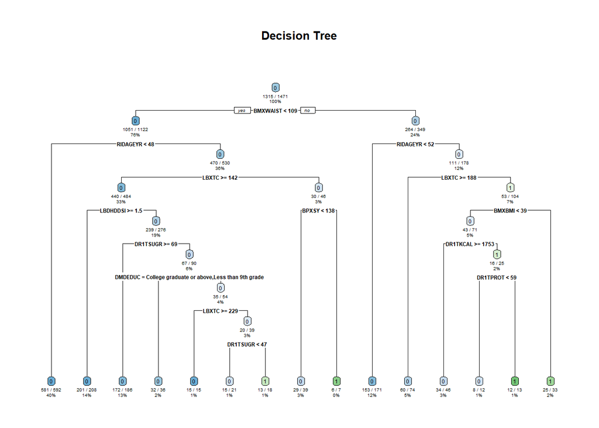

```r
# 4. Decision Tree

# Convert DIQ010 to a factor
train_set$DIQ010 <- as.factor(train_set$DIQ010)
test_set$DIQ010 <- as.factor(test_set$DIQ010)

# Fit
dt_model <- rpart(DIQ010 ~ ., data = train_set, method = "class")

# Predict
dt_predictions_prob <- predict(dt_model, newdata = test_set, type = "prob")[,2]
dt_predictions_label <- ifelse(dt_predictions_prob > 0.5, 1, 0)

# diagnostics
dt_conf_matrix <- table(test_set$DIQ010, dt_predictions_label)
dt_accuracy <- mean(dt_predictions_label == test_set$DIQ010)
dt_sensitivity <- dt_conf_matrix[2,2] / sum(dt_conf_matrix[2,])
dt_specificity <- dt_conf_matrix[1,1] / sum(dt_conf_matrix[1,])

# Plot the decision tree with rpart.plot package for a better visualization
rpart.plot(dt_model, main="Decision Tree", extra=102, under=TRUE, faclen=0)
```

```r
# ROC curve
roc_dt <- roc(response = test_set$DIQ010, predictor = dt_predictions_prob)

# AUC
auc_dt <- auc(roc_dt)
```

3.2.5 Random Forest

```r
# 5. Random Forest
rf_model <- randomForest(DIQ010 ~ ., data = train_set, ntree = 500, mtry = sqrt(ncol(train_set) - 1))

# Convert DIQ010 to a factor
train_set$DIQ010 <- as.factor(train_set$DIQ010)
test_set$DIQ010 <- as.factor(test_set$DIQ010)

# train
rf_model <- randomForest(DIQ010 ~ ., data = train_set)

# predict
rf_predictions_prob <- predict(rf_model, newdata = test_set, type = "prob")
rf_predictions_label <- ifelse(rf_predictions_prob[,2] > 0.5, 1, 0)

# diagnostics
rf_conf_matrix <- table(test_set$DIQ010, rf_predictions_label)
rf_accuracy <- mean(rf_predictions_label == test_set$DIQ010)
rf_sensitivity <- rf_conf_matrix[2,2] / sum(rf_conf_matrix[2,])
rf_specificity <- rf_conf_matrix[1,1] / sum(rf_conf_matrix[1,])

# ROC curve
roc_rf <- roc(response = test_set$DIQ010, predictor = rf_predictions_prob[,2])

# AUC
auc_rf <- auc(roc_rf)
```

3.3 Comparison between different models 3.3.1 ROC and AUC

```r
# summary table
model_performance <- data.frame(
  Model = c("Logistic Regression", "Naive Bayes", "KNN", "Random Forest", "Decision Tree"),
  Accuracy = c(logit_accuracy, nb_accuracy, knn_accuracy, rf_accuracy, dt_accuracy),
  Sensitivity = c(logit_sensitivity, nb_sensitivity, knn_sensitivity, rf_sensitivity, dt_sensitivity),
  Specificity = c(logit_specificity, nb_specificity, knn_specificity, rf_specificity, dt_specificity),
  AUC = c(auc_logit, auc_nb, auc_knn, auc_rf, auc_dt)
)

# Round to three decimal
numeric_columns <- sapply(model_performance, is.numeric)
model_performance[numeric_columns] <- lapply(model_performance[numeric_columns], function(x) round(x, 3))

model_performance
```

```
##                 Model Accuracy Sensitivity Specificity   AUC
## 1 Logistic Regression    0.876       0.186       0.985 0.802
## 2         Naive Bayes    0.832       0.419       0.897 0.755
## 3                 KNN    0.849       0.174       0.956 0.665
## 4       Random Forest    0.873       0.105       0.994 0.819
## 5       Decision Tree    0.863       0.267       0.958 0.789
```

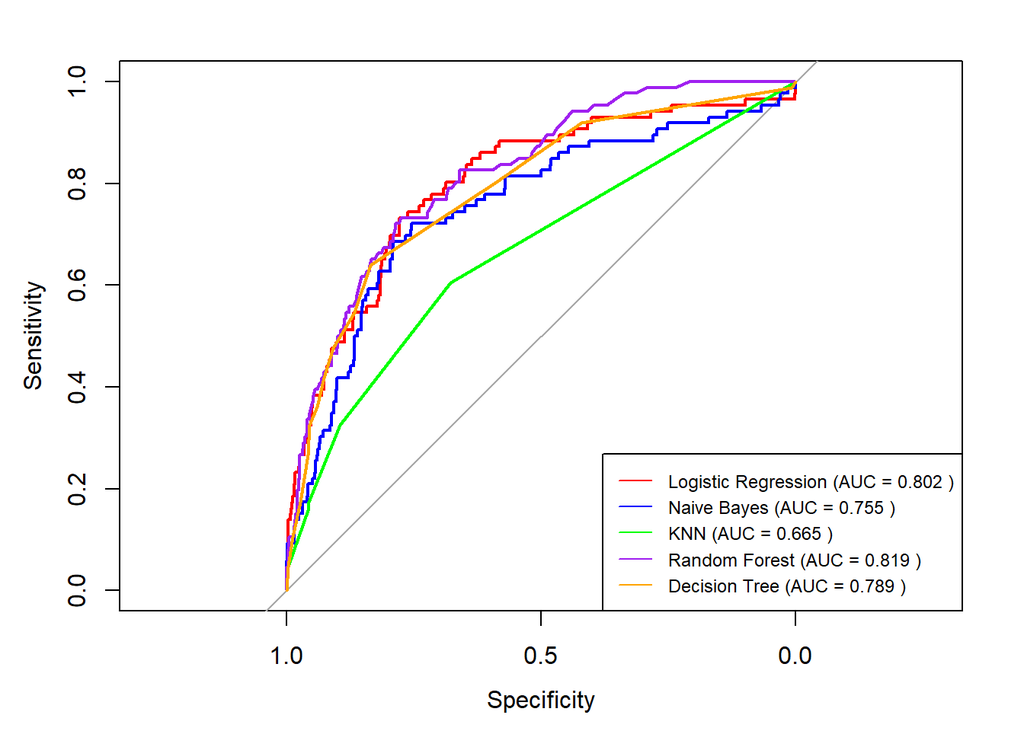

```r
# summary figure
plot(roc_logit, col = "red")
lines(roc_nb, col = "blue")
lines(roc_knn, col = "green")
lines(roc_rf, col = "purple")
lines(roc_dt, col = "orange")

legend_labels <- c(
  paste("Logistic Regression (AUC =", round(auc_logit, 3),")"),
  paste("Naive Bayes (AUC =", round(auc_nb, 3),")"),
  paste("KNN (AUC =", round(auc_knn, 3),")"),
  paste("Random Forest (AUC =", round(auc_rf, 3),")"),
  paste("Decision Tree (AUC =", round(auc_dt, 3),")")
)

legend("bottomright", legend = legend_labels, col = c("red", "blue", "green", "purple", "orange"), lty = 1, cex = 0.75)
```

3.3.2 Performance

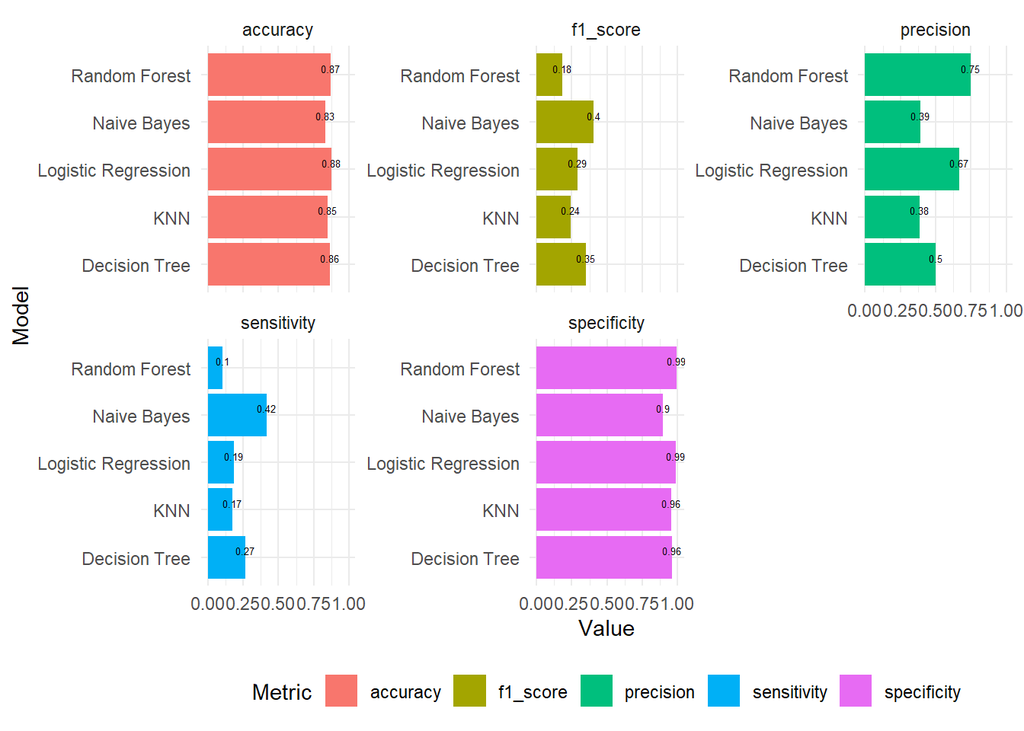

```r
## Performance of the models

binary_class_metric <- function(true, predict, positive_level) {
  # Ensure arguments are factors and have same levels
  true <- factor(true, levels = c(positive_level, ifelse(positive_level == "1", "0", "1")))
  predict <- factor(predict, levels = levels(true))

  # metrics
  tp = sum(true == positive_level & predict == positive_level)  # True Positives
  fn = sum(true == positive_level & predict != positive_level)  # False Negatives
  tn = sum(true != positive_level & predict != positive_level)  # True Negatives
  fp = sum(true != positive_level & predict == positive_level)  # False Positives

  accuracy = (tp + tn) / (tp + tn + fp + fn)
  precision = tp / (tp + fp)
  sensitivity = tp / (tp + fn)  #true positive
  specificity = tn / (tn + fp)
  f1_score = 2 * precision * sensitivity / (precision + sensitivity)

  return(list(accuracy = accuracy,
              precision = precision,
              sensitivity = sensitivity,
              specificity = specificity,
              f1_score = f1_score)) }

dt_metrics <- binary_class_metric(true = test_set$DIQ010, predict = dt_predictions_label, positive_level = "1")

# Evaluation
logit_metric=binary_class_metric(true=test_set$DIQ010,
                                 predict=logit_predictions_label,
                                 positive_level=1)

naive_bayes_metric=binary_class_metric(true=test_set$DIQ010,
                                 predict=nb_predictions_label,
                                 positive_level=1)

knn_metric=binary_class_metric(true=test_set$DIQ010,
                                 predict=knn_predictions,
                                 positive_level=1)

rf_metric=binary_class_metric(true=test_set$DIQ010,
                                 predict=rf_predictions_label,
                                 positive_level=1)



# Create name list
metrics_list <- list(
  "Logistic Regression" = logit_metric,
  "Naive Bayes" = naive_bayes_metric,
  "KNN" = knn_metric,
  "Random Forest" = rf_metric,
  "Decision Tree" = dt_metrics
)

# Combine to one dataframe
results_df <- bind_rows(metrics_list, .id = 'model') %>%
  pivot_longer(cols = -model,
               names_to = 'metric',
               values_to = 'value')

# Plot
ggplot(results_df, aes(x = model, y = value, fill = metric)) +
  geom_col(position = position_dodge()) +
  geom_text(aes(label = round(value, 2)), vjust = -0.3, position = position_dodge(width = 0.9), size = 1.7) +
  facet_wrap(~metric, scales = 'free_y') +
  labs(x = "Model",
       y = "Value",
       fill = "Metric") +
  coord_flip() +
  theme_minimal() +
  theme(legend.position = "bottom")
```

3.3.3 Visualization of Random Forest

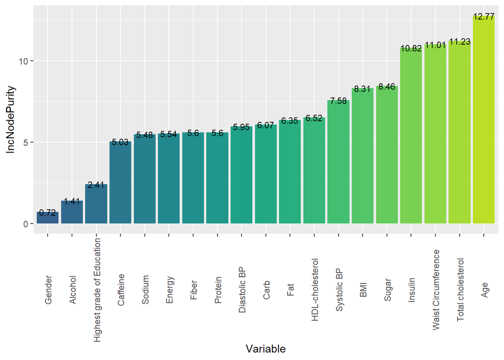

```r
set.seed(123)
index <- createDataPartition(final_df$DIQ010, p = 0.7, list = TRUE)
train_set <- final_df[index[[1]], ]
test_set <- final_df[-index[[1]], ]

rf_model <- randomForest(DIQ010 ~ ., data = train_set, ntree = 500, mtry = sqrt(ncol(train_set) - 1))

# Extract variable importance
importance <- importance(rf_model)
importance_df <- as.data.frame(importance)
importance_df$Variable <- row.names(importance_df)


importance_df <- importance_df %>%
  mutate(Variable = fct_reorder(Variable, IncNodePurity))


# Create a named vector of actual names
actual_names <- c(
  RIAGENDR = "Gender",
  RIDAGEYR = "Age",
  DMDEDUC = "Highest grade of Education",
  BPXDI = "Diastolic BP",
  BPXSY = "Systolic BP",
  BMXBMI = "BMI",
  BMXWAIST = "Waist Circumference",
  LBXTC = "Total cholesterol",
  LBDHDDSI = "HDL-cholesterol",
  LBDINSI = "Insulin",
  DR1TKCAL = "Energy",
  DR1TPROT = "Protein",
  DR1TTFAT = "Fat",
  DR1TCARB = "Carb",
  DR1TFIBE = "Fiber",
  DR1TSUGR = "Sugar",
  DR1TSODI = "Sodium",
  DR1TALCO = "Alcohol",
  DR1TCAFF = "Caffeine"
)

# Replace factor levels with names
importance_df$Variable <- factor(importance_df$Variable, levels = names(actual_names), labels = actual_names)

# Reorder
importance_df <- importance_df %>%
  mutate(Variable = fct_reorder(Variable, IncNodePurity))

# plot
ggplot(importance_df, aes(y = Variable, x = IncNodePurity, fill = Variable)) +
  geom_col(show.legend = FALSE) +
  coord_flip() +
  scale_fill_viridis_d(option = "D", begin = 0.3, end = 0.9) +
  geom_text(aes(label = round(IncNodePurity, 2)),
            hjust = 0.5,
            size = 3.0) +
  theme(axis.text.x = element_text(angle = 90, vjust = 0.5))
```

#### Q4. Recommendations for a non-technical audience

After evaluating various health-related factors and their impact in diabetes, we highly recommend focusing on monitoring and managing age, cholesterol levels, waist circumference, insulin, and sugar intake, as they have been identified as key predictors of diabetes. Using such predictive models can be beneficial in the early identification of individuals at risk, allowing for timely interventions for diabetes. Detailed suggestions include:

**1) Prioritize age management:** While age is a non-modifiable factor, annually body tests and diabetes screening are necessary, especially for the elderly.

**2) Monitor cholesterol and waist circumference:** High total cholesterol and larger waist circumference are strong indicators of potential cardiovascular risk. Regular monitoring and lifestyle interventions such as diet and exercise can be effective.

**3) Reduce sugar intake and insulin levels:** These are also critical factors in managing diabetes risk.

#### Q5. Any additional information

Additional information for the model’s predictive capability might include genetic markers, detailed dietary patterns, physical activity levels, and psychosocial factors, which could provide a more comprehensive view of an individual’s risk profile.  
Furthermore, gathering longitudinal data could allow for the assessment of how these variables changes over time can also improve the predictive power of the models.